# expert_review_risc

Restarted survey-xS3fZVNL-py3.11 (Python 3.11.2)

```python
import re
from typing import Callable, List, Dict

import pandas as pd
import seaborn as sns
from matplotlib import pyplot as plt

from survey.constants import ExpertReviewsRISC
import os
```

```python
# Check if each file used in this notebook actually exists
required_files = [
    ExpertReviewsRISC.foberhau,
    ExpertReviewsRISC.febner,
    ExpertReviewsRISC.skritzin,
]

for file_path in required_files:
    if not os.path.exists(file_path):
        raise FileNotFoundError(f"Script depends upon the file '{file_path}' which does not exist.")
```

```python
def display_barchart(values: pd.Series, order: List[str] = None, title: str = "", xlabel: str = "", ylabel: str = ""):
    """Display a bar chart for the given values."""
    plt.figure(figsize=(10, 6))
    sns.countplot(x=values, order=order)
    plt.title(title)
    plt.xlabel(xlabel)
    plt.ylabel(ylabel)
    plt.xticks(rotation=45)  # Tilt the x labels by 45 degrees
    plt.show()
```

## Expert reviews RISC

First, we take a look individually at the reviews of the experts.

### Felix Oberhauser

We start with Felix Oberhauser. He ranked the papers by relevance. 1 = very relevant, 2 = relevant, 3 = not very relevant, 4 = irrelevant, 5 = very irrelevant. A paper marked with the letter 'd' might be relevant but are very generic (e.g. not related to the load prediction).

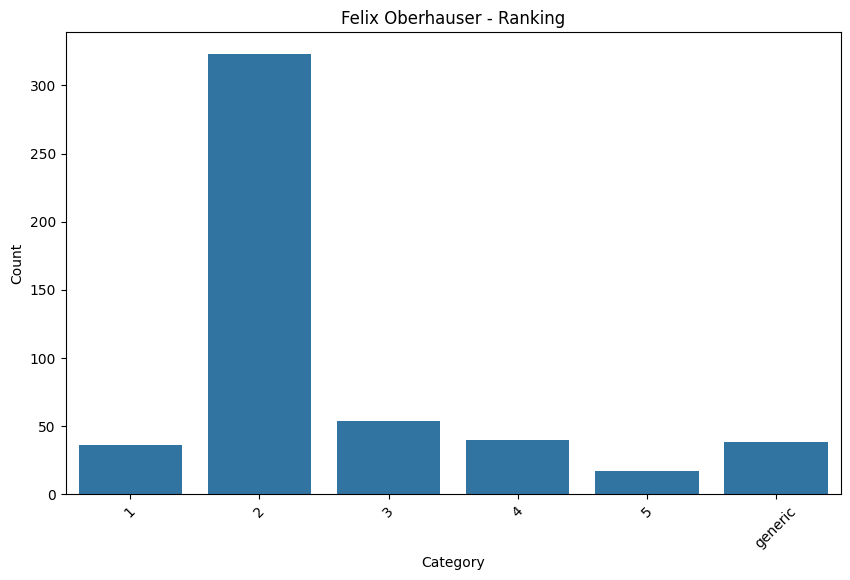

```python
review_foberhau = pd.read_excel(ExpertReviewsRISC.foberhau)
ranking_foberhau = review_foberhau["FOBERHAU"].astype(str)
# map the value 'd' to 'generic'
ranking_foberhau = ranking_foberhau.apply(lambda x: "generic" if x == "d" else x)
display_barchart(
    ranking_foberhau,
    order=["1", "2", "3", "4", "5", "generic"],
    title="Felix Oberhauser - Ranking",
    xlabel="Category",
    ylabel="Count",
)
```

The figure shows we have a small number of very relevant papers. Most papers are rated as relevant or neutral. In his own words, he does not consider 4 or 5 as relevant and while the generic papers might be interesting they are not the focus of the review.

### Franz Ebner

Franz Ebner classified the papers into categories. The categories are unified according to his specification (see dict later on).

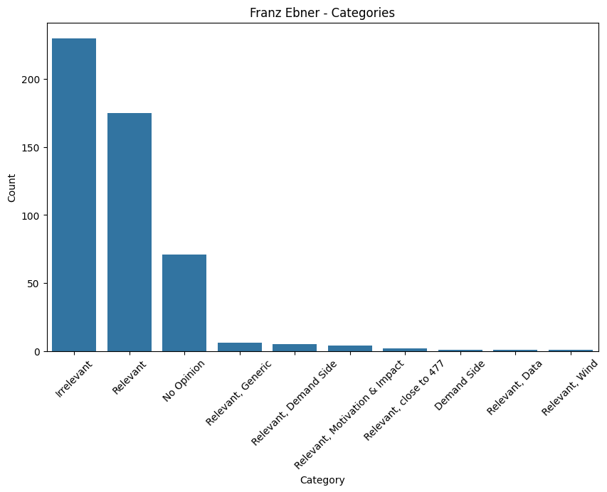

```python
def preprocess_febner(series: pd.Series) -> pd.Series:
    """Preprocess Franz Ebner's categories."""
    def map_category(category):
        if pd.isna(category):
            return "No Opinion"
        if "Irrelevant" in category:
            return "Irrelevant"
        elif "Relevant" in category:
            return category  # Keep the specific category if it's marked as 'Relevant'
        elif "IDK" in category:
            return "No Opinion"
        else:
            return category

    return series.apply(map_category)


review_febner = pd.read_excel(ExpertReviewsRISC.febner)
ranking_febner = preprocess_febner(review_febner["FEBNER"].dropna())
top_n_categories = ranking_febner.value_counts().head(10).index
filtered_ranking_febner = ranking_febner[ranking_febner.isin(top_n_categories)]

display_barchart(
    filtered_ranking_febner, order=top_n_categories, title="Franz Ebner - Categories", xlabel="Category", ylabel="Count"
)
```

The figure shows the top 10 categories Franz Ebner classified the papers into. It seems that many papers were marked as relevant. Many seem to focus not explicitly on demand prediction but rather on exogenous factors and are often marked as irrelevant. Additionally, the reviewer marked some papers as 'IDK' (I don't know).

### Stefanie Kritzinger-Griebler

Finished the review and seemed rather strict in her ratings. She rated the papers from 1 to 5.

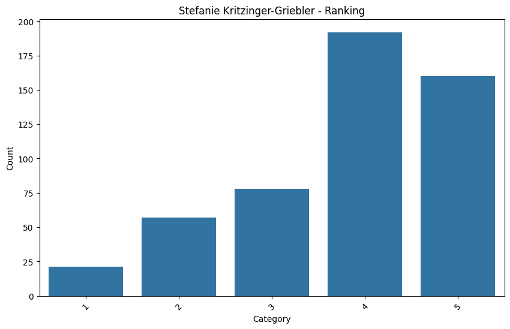

```python
review_skritzin = pd.read_excel(ExpertReviewsRISC.skritzin)
ranking_skritzin = review_skritzin["SKRITZIN"].astype(str)
display_barchart(
    ranking_skritzin,
    order=["1", "2", "3", "4", "5"],
    title="Stefanie Kritzinger-Griebler - Ranking",
    xlabel="Category",
    ylabel="Count",
)
```

## Summary

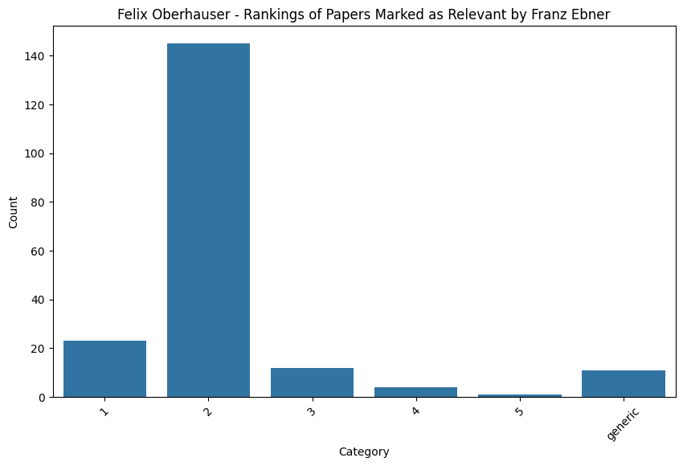

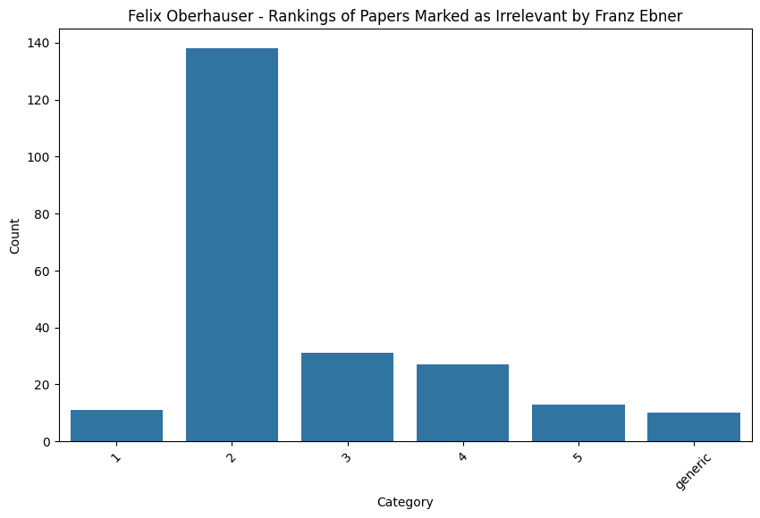

```python
# Filter relevant and irrelevant papers based on Franz Ebner's rankings
relevant_indices = ranking_febner[ranking_febner.str.contains("Relevant")].index
relevant_foberhau = ranking_foberhau.loc[relevant_indices]
display_barchart(
    relevant_foberhau,
    order=["1", "2", "3", "4", "5", "generic"],
    title="Felix Oberhauser - Rankings of Papers Marked as Relevant by Franz Ebner",
    xlabel="Category",
    ylabel="Count",
)

irrelevant_indices = ranking_febner[ranking_febner.str.contains("Irrelevant")].index
irrelevant_foberhau = ranking_foberhau.loc[irrelevant_indices]
display_barchart(
    irrelevant_foberhau,
    order=["1", "2", "3", "4", "5", "generic"],
    title="Felix Oberhauser - Rankings of Papers Marked as Irrelevant by Franz Ebner",
    xlabel="Category",
    ylabel="Count",
)
```

## Agreement between experts

We calculate the agreement between experts by comparing the categories they assigned to the papers. To accomplish this, we define synonyms (meaning these fall in the same category), and look at how much agreement there is between the experts.

### Example

In the following example, we have three experts who have rated a set of papers. We define synonyms for each expert to account for variations in their terminology.

[output not shown]

````python
#     """Replace synonyms with the unique value and create a boolean series."""
#     return series.apply(lambda x: any(comparison(x, synonym) for synonym in synonyms))
#
# def compare_experts(
#     expert_rankings: pd.DataFrame,
#     synonyms: Dict[str, List[str]],
#     comparison: Callable[[str, str], bool] = lambda expert_opinion, synonym: expert_opinion.lower() == synonym.lower(),
# ) -> pd.Series:
#     """Compare the agreement between experts."""
#     data = {}
#     for expert in expert_rankings.columns:
#         data[expert] = find_category(expert_rankings[expert], synonyms[expert], comparison)
#
#     agreement = pd.DataFrame(data, index=expert_rankings.index)
#     agreement_percent = agreement.sum(axis=1) / agreement.shape[1]
#     agreement_percent.name = "Agreement Percentage"
#     return agreement_percent, agreement
#
# agreement_percent, agreement = compare_experts(expert_rankings, synonyms)
# ```
#
# ### Why this is a good idea
# - **Standardization**: By defining synonyms, we standardize the terminology used by different experts, making it easier to compare their ratings.
# - **Quantitative Analysis**: The agreement percentage provides a quantitative measure of how much the experts agree with each other.
# - **Identifying Discrepancies**: This method helps in identifying areas where experts disagree, which can be useful for further discussions and analysis.
#
# ### Potential Drawbacks
# - **Subjectivity**: The choice of synonyms is subjective and may not capture all nuances in the experts' ratings.
# - **Loss of Information**: Simplifying ratings into broader categories may result in the loss of detailed information.

data = {
    "Expert1": ["Relevant", "Irrelevant, Wind", "Relevant, Generic", "IDK", "Irrelevant"],
    "Expert2": ["Relevant", "Rekevant", "Relevant", "IDK", "Irrelevant, Solar"],
    "Expert3": ["Relevant", "Irrelevant", "Relevant, Demand Side", "IDK", "Irrelevant, Generic"],
}
expert_rankings = pd.DataFrame(data)

synonyms = {"Expert1": ["relevant"], "Expert2": ["Relevant", "Rekevant"], "Expert3": ["Relevant, Demand Side"]}


def find_category(
    series: pd.Series,
    synonyms: List[str],
    comparison: Callable[[str, str], bool] = lambda expert_opinion, synonym: expert_opinion.lower() == synonym.lower(),
) -> pd.Series:
    """Replace synonyms with the unique value and create a boolean series."""
    return series.apply(lambda x: any(comparison(x, synonym) for synonym in synonyms))


def compare_experts(
    expert_rankings: pd.DataFrame,
    synonyms: Dict[str, List[str]],
    comparison: Callable[[str, str], bool] = lambda expert_opinion, synonym: expert_opinion.lower() == synonym.lower(),
) -> pd.Series:
    """Compare the agreement between experts."""
    data = {}
    for expert in expert_rankings.columns:
        data[expert] = find_category(expert_rankings[expert], synonyms[expert], comparison)

    agreement = pd.DataFrame(data, index=expert_rankings.index)
    agreement_percent = agreement.sum(axis=1) / agreement.shape[1]
    agreement_percent.name = "Agreement Percentage"
    return agreement_percent, agreement


agreement_percent, agreement = compare_experts(expert_rankings, synonyms)

agreement_table = pd.concat([agreement_percent, agreement], axis=1)
print('Example agreement table:')
print(agreement_table.to_string(index=False, header=True))
````

```
Example agreement table:
 Agreement Percentage  Expert1  Expert2  Expert3
             0.666667     True     True    False
             0.333333    False     True    False
             0.666667    False     True     True
             0.000000    False    False    False
             0.000000    False    False    False
```

```python
expert_rankings = pd.DataFrame(
    {
        "FEBNER": review_febner["FEBNER"].astype(str),
        "FOBERHAUSER": ranking_foberhau,
        "SKRITZIN": ranking_skritzin,
    },
    index=review_febner.index,
)

# Define synonyms for relevant and irrelevant papers
synonyms_relevant = {
    "FEBNER": [
        "Relevant",
        "Demand Side",
        "Relevant, Generic",
        "Relevant, Motivation & Impact",
        "Relevant, Data",
        "Relevant, Wind",
        "Relevant, Demand Side",
        "Rekevant",
        "Highly? Relevant",
        "Relevant, Motivation",
        "Relevant, close to 477",
        'No Opinion',  # no opinion = agree with other experts
    ],
    "FOBERHAUSER": ["1", "2"],
    "SKRITZIN": ["1", "2", "3"],
}

synonyms_irrelevant = {
    "FEBNER": [
        "Irrelevant",
        "Review, Generic",
        #    'No Opinion',  # no opinion = agree with other experts
    ],
    "FOBERHAUSER": ["3", "4", "5", "generic"],
    "SKRITZIN": ["4", "5"],
}

experts_agreement_relevant, _ = compare_experts(expert_rankings, synonyms_relevant)
experts_agreement_irrelevant, _ = compare_experts(expert_rankings, synonyms_irrelevant)
```

```python
def plot_agreement(
    agreement_percentage: pd.Series,
    title: str = "Agreement Percentage Distribution (Relevant Papers)",
):
    """Plot the agreement percentage distribution."""
    plt.figure(figsize=(10, 6))
    sns.barplot(x=agreement_percentage.index, y=agreement_percentage.values)
    plt.title(title)
    plt.xlabel("Agreement Percentage")
    plt.ylabel("Count")
    plt.show()
```

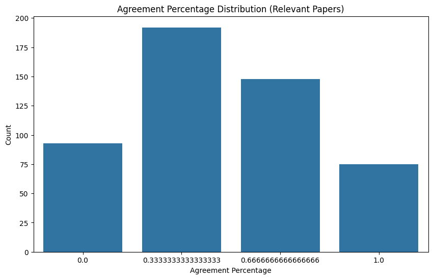

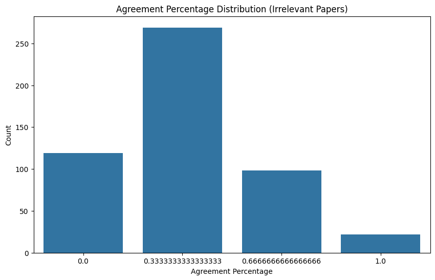

```python
plot_agreement(experts_agreement_relevant.value_counts(), title="Agreement Percentage Distribution (Relevant Papers)")
plot_agreement(
    experts_agreement_irrelevant.value_counts(), title="Agreement Percentage Distribution (Irrelevant Papers)"
)
```

## Weather or Renewable Related Papers

We check if the papers are related to weather or renewables.

```python
weather_keywords = ["wind", "pv", "solar", "photovoltaic", "weather", "hydro"]
weather_related = (
    review_foberhau["manual_classification"].str.lower().str.contains("|".join(weather_keywords), case=False, na=False)
)

experts_relevant = pd.DataFrame(
    {
        "agreement": experts_agreement_relevant.values,
        "is_weather_related": weather_related,
        "classification": review_foberhau["manual_classification"],
    }
)
experts_irrelevant = pd.DataFrame(
    {
        "agreement": experts_agreement_irrelevant.values,
        "is_weather_related": weather_related,
        "classification": review_foberhau["manual_classification"],
    }
)
```

```python
def process_categories(data: pd.Series, threshold: float = 3.0) -> pd.Series:
    """Process categories and mark less common categories as 'Other'."""
    all_categories = data.str.split(",").explode()
    category_counts = all_categories.value_counts()

    data = data.map(lambda x: x.split(",") if "," in x else [x])
    most_common_category = data.map(lambda category: max(category, key=lambda x: category_counts.get(x, 0)))

    category_translation = category_counts.apply(lambda x: x if x >= threshold else "Other")
    category_mapping = {
        category: (category if count != "Other" else "Other") for category, count in category_translation.items()
    }

    most_common_category = most_common_category.map(category_mapping)

    return most_common_category
```

```python
def create_stacked_plot(
    data: pd.DataFrame,
    by: List[str] = ["agreement", "simple_categories"],
    *,
    ax: plt.Axes = None,
    size_threshold_container_size: int = 7,
) -> plt.Axes:
    """Create a stacked plot for the given data."""
    aggregated_data = data.groupby(by).size().unstack(fill_value=0)
    ax = aggregated_data.plot(kind="bar", stacked=True, figsize=(10, 6), colormap="tab20", ax=ax)

    ax.spines['top'].set_visible(False)
    ax.spines['right'].set_visible(False)
    ax.spines['left'].set_visible(False)
    ax.spines['bottom'].set_visible(False)

    for container in ax.containers:
        labels = [f'{int(v.get_height())}' if v.get_height() > size_threshold_container_size else '' for v in container]
        ax.bar_label(container, labels=labels, label_type='center', padding=3, fontsize=10, color='white')

    ax.set_xticklabels([f'{x:.3f}' for x in aggregated_data.index], rotation=45)
    return ax
```

The next figure shows how much papers related to renewables and weather take up from the total set.

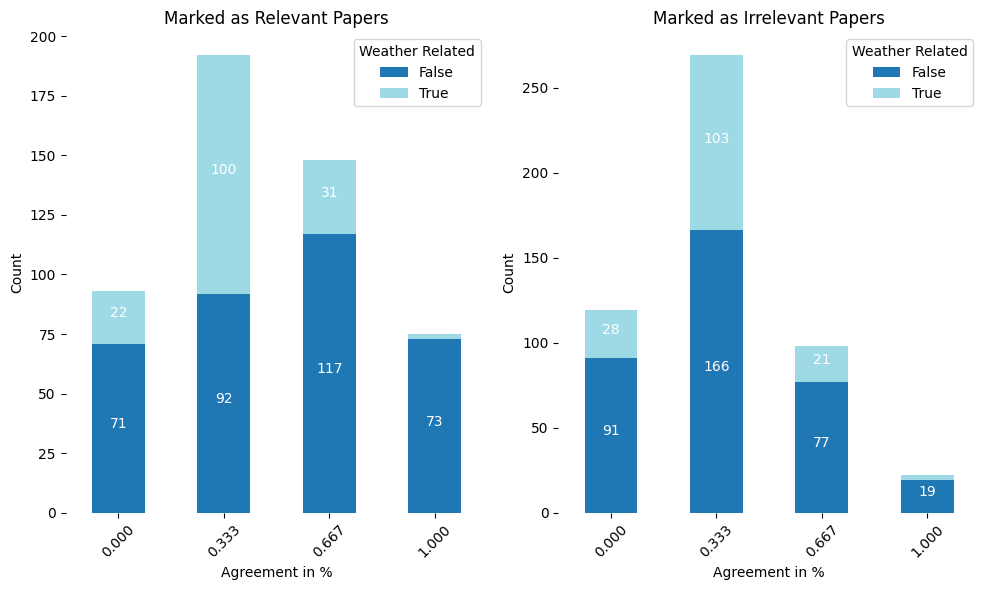

```python
fig, (ax1, ax2) = plt.subplots(1, 2, figsize=(20, 6))
create_stacked_plot(
    experts_relevant,
    by=["agreement", "is_weather_related"],
    ax=ax1,
)
ax1.legend(title="Weather Related")
ax1.set_xlabel("Agreement in %")
ax1.set_ylabel("Count")
ax1.set_title("Marked as Relevant Papers")

create_stacked_plot(
    experts_irrelevant,
    by=["agreement", "is_weather_related"],
    ax=ax2,
)
ax2.legend(title="Weather Related")
ax2.set_xlabel("Agreement in %")
ax2.set_ylabel("Count")
ax2.set_title("Marked as Irrelevant Papers")

fig.tight_layout()
fig.show()
```

Aggregate the data by agreement and category, without weather!

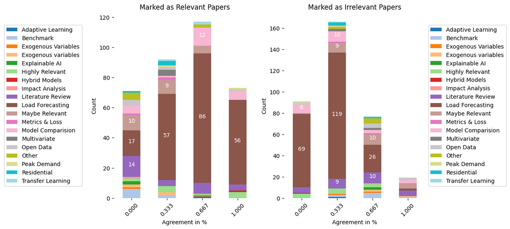

```python
fig, (ax1, ax2) = plt.subplots(1, 2, figsize=(20, 6))
data = experts_relevant[~experts_relevant["is_weather_related"]]["classification"]
data = data.map(lambda x: x.replace(" litr", "Literature Review"))
data = data.map(lambda x: x.replace(",Uncertainty", "Literature Review"))
experts_relevant["simple_categories"] = process_categories(data)
create_stacked_plot(experts_relevant, ax=ax1)
ax1.set_xlabel("Agreement in %")
ax1.set_ylabel("Count")
ax1.set_title("Marked as Relevant Papers")
ax1.legend(loc="upper center", bbox_to_anchor=(-0.5, 0.95))

data = experts_irrelevant[~experts_irrelevant["is_weather_related"]]["classification"]
data = data.map(lambda x: x.replace(" litr", "Literature Review"))
data = data.map(lambda x: x.replace(",Uncertainty", "Literature Review"))
experts_irrelevant["simple_categories"] = process_categories(data)
create_stacked_plot(experts_irrelevant, ax=ax2)
ax2.set_xlabel("Agreement in %")
ax2.set_ylabel("Count")
ax2.set_title("Marked as Irrelevant Papers")
ax2.legend(loc="center left", bbox_to_anchor=(1, 0.5))

fig.show()
```

## Combining Opinions

We select the threshold at >=0.6, which implies 2 out of 3 experts agree that the paper is relevant or irrelevant.

```python
threshold = 0.6

all_papers = set(experts_agreement_relevant.index)
set_of_relevant_papers = set(
    experts_agreement_relevant[experts_agreement_relevant >= threshold].index
)
set_of_irrelevant_papers = set(
    experts_agreement_irrelevant[experts_agreement_irrelevant >= threshold].index
)
weather_related = experts_relevant[experts_relevant['is_weather_related']].index

# only important papers
experts_selection = all_papers.intersection(set_of_relevant_papers).difference(set_of_irrelevant_papers)
relevant_weather_papers = all_papers.intersection(set_of_relevant_papers).intersection(weather_related)
```

```
Axes(0.125,0.11;0.775x0.77)
```

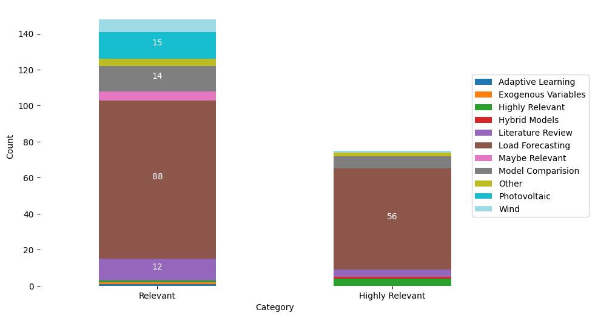

```python
data = experts_relevant["classification"]
data = data.loc[list(experts_selection)]
data = data.map(lambda x: x.replace(" litr", "Literature Review"))
data = data.map(lambda x: x.replace(",Uncertainty", "Literature Review"))

experts_relevant["simple_categories"] = process_categories(data)
ax = create_stacked_plot(experts_relevant)
ax.set_xlabel("Category")
ax.set_ylabel("Count")
ax.set_xticklabels(["Relevant", "Highly Relevant"], rotation=0)
ax.legend(loc="center left", bbox_to_anchor=(0.91, 0.5))
print(ax)
```

```python
categoriesed = (
    experts_relevant
        .loc[list(experts_selection)]
        .apply(lambda x: 'Highly Relevant' if x['agreement'] == 1 else "Relevant", axis=1)
)

categoriesed_weather = (
    experts_relevant
        .loc[list(weather_related.difference(experts_selection))]
        .apply(lambda x: "Weather or Renewable Related", axis=1)
)
categoriesed = pd.concat([categoriesed, categoriesed_weather])

categories = categoriesed.unique()
result = {category: set(categoriesed[categoriesed == category].index) for category in categories}

# Check for overlapping categories
all_indices = set()
for category, indices in result.items():
    if all_indices.intersection(indices):
        raise ValueError(f"Overlapping indices found in category: {category}")
    all_indices.update(indices)
```

```python
def normalize_journal_name(name):
    # if an NA is found
    if pd.isna(name):
        return name

    # remove list brackets and quotes at the beginning and end
    name = re.sub(r"^\[|\]$", "", name)
    name = re.sub(r"^'|'$", "", name)
    name = name.replace('"', '').strip()
    return name

library = (
    review_foberhau
        .copy()
        .drop(columns=[
            'Unnamed: 0', 'Ratind; 1=Very Relevant; 5=Irrelevant',
            'Ranking 1=Very Relevant; 5=Irrelevant', 'Unnamed: 17', 'FOBERHAU',
            'Kategorien',
       ])
       .assign(journal_or_conference_name=lambda x: x['journal_or_conference_name'].apply(normalize_journal_name))
)


# ensure manually added papers are retained
manually_added = set(library[library['source'] == 'Manual Search'].index)
manual_to_add = manually_added.difference(all_indices)
if manual_to_add:
    result['Manual Search'] = manual_to_add

with pd.ExcelWriter(ExpertReviewsRISC.agreement) as writer:
    for category, indices in result.items():
        category_papers = library.loc[list(indices)]
        category_papers.to_excel(writer, sheet_name=category)
```